# Differential peak analysis test

This notebook was used to generate the figures for the paper. It is an example on how you can do differential peak analysis from HiChIP peaks tool.

set environment requirements

```r
setwd("~/GitHub/domain_caller_site_development/diff_analysis_tests")
require("DESeq2")
require("tximport")
library("dplyr")
library("ggplot2")
library("pheatmap")
library("RColorBrewer")
library("apeglm")
library("GenomicFeatures")
library("AnnotationDbi")
library("org.Hs.eg.db")
library("TxDb.Hsapiens.UCSC.hg38.knownGene")
library("EnsDb.Hsapiens.v86")
```

test 1 our software and algorithm can differentiate technical replicates from biological replicates

```r
## load data
data <- read.csv(file="diff_peaks_results.csv",header=TRUE)
# select the columns with data and convert to properly formatted dataframe
count_data <- data[3:6]
colnames_data<-colnames(count_data)
# DESeq2 requires all numbers to be integers so round
count_data=sapply(1:ncol(count_data), function(x) round(count_data[, x], 0))
# set the rownames as peaks IDs
rownames(count_data) <- data[,1]
# set sample conditions
info<-c("B3","B3","B2","B2")
colnames_data->colnames(count_data)
conditions <-data.frame(info,row.names=colnames(count_data))
# Remove values less than 0
count_data <- replace(count_data, count_data < 0, 0)
#convert to deseq2 dataset
dds<- DESeqDataSetFromMatrix(countData = count_data,
                              colData = conditions,
                              design = ~ info)
```

exploratory data analysis. Clustering and PCA

```r
#NORMALIZATION, NOT ACTUALLY USED FOR DESeq2
# this is basically standardization of  for pca and clustering
# see DESeq2 vignette for more info
rld <- rlog(dds, blind = TRUE)
#vsd is the reccomended method for normal things. use the plots from vsd normalization
vsd <- vst(dds, blind = TRUE)
dds <- DESeq(dds)
##VISUALIZATION OF NORMALIZATION
df <- bind_rows(
  as_data_frame(log2(counts(dds, normalized=TRUE)[, 1:2]+1)) %>%  mutate(transformation = "log2(x + 1)"),
  as_data_frame(assay(vsd)[, 1:2]) %>% mutate(transformation = "vst"),
  as_data_frame(assay(rld)[, 1:2]) %>% mutate(transformation = "rlog"))
```

```
`as_data_frame()` is deprecated, use `as_tibble()` (but mind the new semantics).
```

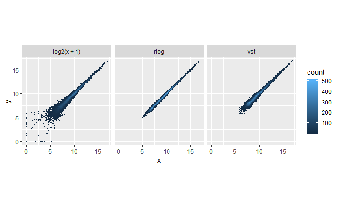

```r
#basically sample 1 and 2
colnames(df)[1:2] <- c("x", "y")
ggplot(df, aes(x = x, y = y)) + geom_hex(bins = 80) +
  coord_fixed() + facet_grid( . ~ transformation)
##SAMPLE CLUSTERING DISTANCES(EUCLIDEAN)
#with vsd
sampleDists <- dist(t(assay(rld)))
sampleDistMatrix <- as.matrix( sampleDists )
#rownames(sampleDistMatrix) <-  conditions[1:4,]
colnames(sampleDistMatrix) <- NULL
colors <- colorRampPalette( rev(brewer.pal(9, "Blues")) )(255)
pheatmap(sampleDistMatrix,
         clustering_distance_rows = sampleDists,
         clustering_distance_cols = sampleDists,
         filename = "clustering_naive.pdf",
         col = colors, main="Clustering of replicates for Naive T cells \n rlog normalization")
```

```r
#with rlog
sampleDists <- dist(t(assay(vsd)))
sampleDistMatrix <- as.matrix( sampleDists )
#rownames(sampleDistMatrix) <-   conditions[1:4,]
colnames(sampleDistMatrix) <- NULL
colors <- colorRampPalette( rev(brewer.pal(9, "Blues")) )(255)
pheatmap(sampleDistMatrix,
         clustering_distance_rows = sampleDists,
         clustering_distance_cols = sampleDists,
         col = colors, main="Clustering of replicates for Naive T cells \n vst normalization")
##PCA PLOTS
plotPCA(rld,intgroup=c("info"))
```

[output not shown]

```r
plotPCA(vsd,intgroup=c("info"))
pcaData <- plotPCA(vsd,intgroup=c("info"),returnData = TRUE)
pcaData
```

|  | PC1 | PC2 | group | info | name |
| --- | --- | --- | --- | --- | --- |
| NaiveT_27ac_B3_T1 | -22.93920 | 2.8228194 | B3 | B3 | NaiveT_27ac_B3_T1 |
| NaiveT_27ac_B3_T2 | -20.75890 | -2.9662493 | B3 | B3 | NaiveT_27ac_B3_T2 |
| NaiveT_27ac_B2_T2 | 21.87773 | 0.8273163 | B2 | B2 | NaiveT_27ac_B2_T2 |
| NaiveT_27ac_B2_T1 | 21.82037 | -0.6838865 | B2 | B2 | NaiveT_27ac_B2_T1 |

```r
p <- plotPCA(vsd,intgroup=c("info"))
p <- p + geom_text(aes_string(x = "PC1", y = "PC2", label = "name"), color = "black",size=3)
print(p)
```

[output not shown]

```r
res <- results(dds, contrast=c("info", "B3","B2"),alpha=0.10, lfcThreshold = 0.5)
summary(res)
```

```
out of 24440 with nonzero total read count
adjusted p-value < 0.1
LFC > 0.50 (up)    : 1841, 7.5%
LFC < -0.50 (down) : 1157, 4.7%
outliers [1]       : 0, 0%
low counts [2]     : 0, 0%
(mean count < 50)
[1] see 'cooksCutoff' argument of ?results
[2] see 'independentFiltering' argument of ?results
```

```r
resOrdered <- res[order(res$pvalue),]
resOrderedDF <- as.data.frame(resOrdered)
resOrderedDF
```

|  | baseMean | log2FoldChange | lfcSE | stat | pvalue | padj |
| --- | --- | --- | --- | --- | --- | --- |
| peak_9698 | 9656.71316 | 4.5919096 | 0.09282391 | 44.082496 | 0.000000e+00 | 0.000000e+00 |
| peak_18861 | 19769.24806 | -3.1738459 | 0.06877274 | -38.879445 | 0.000000e+00 | 0.000000e+00 |
| peak_10564 | 3670.28074 | 4.2524760 | 0.11096273 | 33.817443 | 1.092978e-250 | 8.904125e-247 |
| peak_19282 | 31841.36720 | -2.5917131 | 0.06853267 | -30.521399 | 1.355498e-204 | 8.282092e-201 |
| peak_12553 | 9758.46861 | 2.5982603 | 0.06894863 | 30.432227 | 2.058947e-203 | 1.006413e-199 |
| peak_8453 | 4722.67509 | 2.8793135 | 0.08188036 | 29.058417 | 1.204628e-185 | 4.906852e-182 |
| peak_8452 | 4626.52913 | 3.1007077 | 0.09378043 | 27.731880 | 2.882386e-169 | 1.006364e-165 |
| peak_12554 | 13163.09964 | 2.2067756 | 0.06580505 | 25.936849 | 2.558917e-148 | 7.817491e-145 |
| peak_6954 | 2436.83895 | -3.9801371 | 0.13454395 | -25.866172 | 1.600567e-147 | 4.346429e-144 |
| peak_17764 | 4026.79628 | 2.5402361 | 0.08403823 | 24.277477 | 3.390870e-130 | 8.287287e-127 |

[output cut: 990 more lines]

```r
# there are 2998 regions that are differentially bound between the two biological replicates
```

Test2 Analysis of the different T cell subtypes

```r
#clean environment first!
rm(list=ls())
#load the dataset for the different T cells subtypes comparison
data <- read.csv(file="T_cells_comparison.csv",header=TRUE)
# select the columns with data and convert to properly formatted dataframe
count_data <- data[3:8]
colnames_data<-colnames(count_data)
# DESeq2 requires all numbers to be integers so round
count_data=sapply(1:ncol(count_data), function(x) round(count_data[, x], 0))
# set the rownames as peaks IDs
rownames(count_data) <- data[,1]
# set sample conditions
info<-c("naive","naive","th17","treg","treg","th17")
colnames_data->colnames(count_data)
conditions <-data.frame(info,row.names=colnames(count_data))
# Remove values less than 0
count_data <- replace(count_data, count_data < 0, 0)
# keep information about peak location into variable
peak_info <- data[1:2]
#convert to deseq2 dataset
dds<- DESeqDataSetFromMatrix(countData = count_data,
                              colData = conditions,
                              design = ~ info)
```

exploratory data analysis

[figure not shown]

execute the next two steps with the different comparisons to get results for each contrast!

```r
res <- results(dds, contrast=c("info", "naive","th17"),alpha=0.10, lfcThreshold = 0.5)
summary(res)
```

```
out of 31589 with nonzero total read count
adjusted p-value < 0.1
LFC > 0.50 (up)    : 2114, 6.7%
LFC < -0.50 (down) : 2041, 6.5%
outliers [1]       : 0, 0%
low counts [2]     : 0, 0%
(mean count < 37)
[1] see 'cooksCutoff' argument of ?results
[2] see 'independentFiltering' argument of ?results
```

```r
resOrdered <- res[order(res$pvalue),]
resOrderedDF <- as.data.frame(resOrdered)
```

this block will create all the databases as well that are needed for the next step as well. it will annotate peaks and save the csv with the p values for that particular contrast(set up above)

```r
#identifying genes changed
#create dataset to convert peaks names to peaks position for Granges
peak_info_postion=lapply(1:nrow(peak_info), function(x) strsplit(as.character(peak_info[x, 2]), split = ":|-")[[1]]);
peak_info_positions=do.call(rbind, peak_info_postion)
peak_info_positions=cbind(as.character(peak_info[,1]), peak_info_positions)
colnames(peak_info_positions)<-c("peak","chr","start","end")
#assign positions to deseq2 dataframe
resOrderedDF_with_loc=merge(x=resOrderedDF, y=peak_info_positions, by.x="row.names", by.y="peak");
peak_genomic_ranges=makeGRangesFromDataFrame(resOrderedDF_with_loc,keep.extra.columns=TRUE,ignore.strand=TRUE)
#create database for promoters. promoters are TSS +- 1kb
edb <- EnsDb.Hsapiens.v86
edb
```

```
EnsDb for Ensembl:
|Backend: SQLite
|Db type: EnsDb
|Type of Gene ID: Ensembl Gene ID
|Supporting package: ensembldb
|Db created by: ensembldb package from Bioconductor
|script_version: 0.3.0
|Creation time: Thu May 18 16:32:27 2017
|ensembl_version: 86
|ensembl_host: localhost
|Organism: homo_sapiens
|taxonomy_id: 9606
|genome_build: GRCh38
|DBSCHEMAVERSION: 2.0
| No. of genes: 63970.
| No. of transcripts: 216741.
|Protein data available.
```

```r
transcripts_DF <- select(edb,keys=keys(edb, keytype="TXID"), columns=c("TXID","SEQNAME", "TXSEQSTART", "TXSEQEND", "SEQSTRAND","TXBIOTYPE","ENTREZID","GENENAME"), keytype="TXID")
find_promoter <- function(line){
  if (as.integer(line["SEQSTRAND"])==1)
  {
    start = as.integer(line["TXSEQSTART"]) - 1000
    end = as.integer(line["TXSEQSTART"]) + 1000
  }
  else
  {
    start = as.integer(line["TXSEQEND"]) - 1000
    end = as.integer(line["TXSEQEND"]) + 1000
  }
  return(c(start,end))
}
temp <- t(apply(transcripts_DF,1,find_promoter))
colnames(temp) <- c("start","end")
transcripts_DF <- cbind(transcripts_DF,temp)
transcripts_DF$SEQNAME <- paste("chr", transcripts_DF$SEQNAME, sep="")
transcripts_promoters = makeGRangesFromDataFrame(transcripts_DF,keep.extra.columns=TRUE,ignore.strand=TRUE)
#all promoters done
#assign promoters to peaks
mcols(peak_genomic_ranges)$genes <- NA
mcols(peak_genomic_ranges)$entrez <- NA
hits <- findOverlaps(query = peak_genomic_ranges, subject = transcripts_promoters, ignore.strand = TRUE)
mcols(peak_genomic_ranges[queryHits(hits)])$genes <- transcripts_promoters[subjectHits(hits)]$GENENAME
mcols(peak_genomic_ranges[queryHits(hits)])$entrez <- transcripts_promoters[subjectHits(hits)]$ENTREZID
annotated_peaks <- as.data.frame(peak_genomic_ranges)
#select the peaks that had a promoter annotated using gene name
annotated_peaks_noNa <- annotated_peaks[!is.na(annotated_peaks$genes),]
#select for significantly different genes
diff_genes = annotated_peaks_noNa[which(annotated_peaks_noNa$padj < 0.10 ),]
#write.table(diff_genes,"naive_vs_th17.csv", row.names = FALSE, col.names = FALSE)
```

this block does the above but uses all peaks from all contrasts, this creates a full database with normalized counts. subsequently it selects the peaks to be viewed as the most differentially expressed between the three contrasts and makes a heatmap

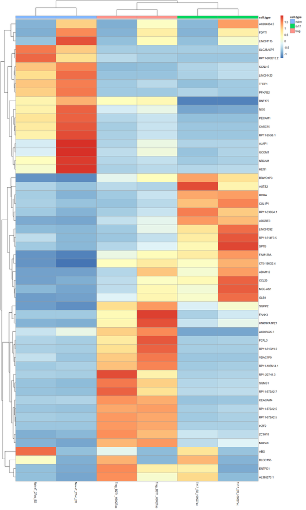

```r
#heatmap of peaks
#take normalized counts, remember that these are not regularized
all_peaks_normalized_counts = as.data.frame(counts( dds, normalized=TRUE ))
all_peaks_normalized_counts_with_pos<-merge(x=all_peaks_normalized_counts, y=peak_info_positions, by.x="row.names", by.y="peak")
all_peaks_normalized_counts_GRanges <- makeGRangesFromDataFrame(all_peaks_normalized_counts_with_pos,keep.extra.columns=TRUE,ignore.strand=TRUE)
mcols(all_peaks_normalized_counts_GRanges)$genes <- NA
mcols(all_peaks_normalized_counts_GRanges)$entrez <- NA
hits <- findOverlaps(query = all_peaks_normalized_counts_GRanges, subject = transcripts_promoters, ignore.strand = TRUE)
mcols(all_peaks_normalized_counts_GRanges[queryHits(hits)])$genes <- transcripts_promoters[subjectHits(hits)]$GENENAME
mcols(all_peaks_normalized_counts_GRanges[queryHits(hits)])$entrez <- transcripts_promoters[subjectHits(hits)]$ENTREZID
annotated_peaks_counts <- as.data.frame(all_peaks_normalized_counts_GRanges)
annotated_peaks_counts_noNa <- annotated_peaks_counts[!is.na(annotated_peaks_counts$genes),]
#peaks annotated and selected!
#the thing that actually selects the peaks to be viewed. change this to view differentially expressed
#remember these counts are not regularized, this means that selecting the most variable is probably selecting peaks that have low expressoin
topVariancepeaks <- rownames(vsd[head(order(rowVars(assay(vsd)), decreasing=T),100),])
selected_peaks = annotated_peaks_counts_noNa[which(annotated_peaks_counts_noNa$Row.names %in% topVariancepeaks),]
matrix <- selected_peaks[7:12]
#this function calculates z scores ot make it more uniform across different expression levels
cal_z_score <- function(x){
  (x - mean(x)) / sd(x)
}
my_sample_col <-  data.frame("cell type" = info)
row.names(my_sample_col) <- colnames(selected_peaks[7:12])
matrix <- t(apply(matrix, 1, cal_z_score))
pheatmap(matrix,
         labels_row = selected_peaks$genes,
         annotation_col = my_sample_col)
```

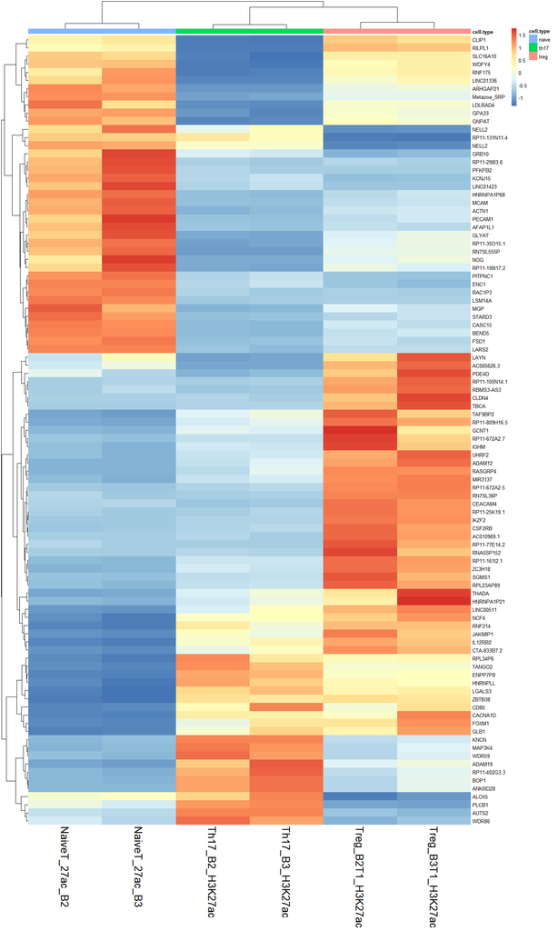

```r
### selecting top DE genes
res <- results(dds, contrast=c("info", "naive","treg"),alpha=0.10, lfcThreshold = 0.5)
topDEpeaks<- rownames(res[head(order(res$pvalue),100),])
write.table(merge(as.data.frame(res[res$padj < 0.10,]),peak_info, by.x="row.names", by.y="X"),"naive_vs_treg_DEpeaks.csv", row.names = TRUE, col.names = TRUE)
res <- results(dds, contrast=c("info", "naive","th17"),alpha=0.10, lfcThreshold = 0.5)
topDEpeaks<- c(topDEpeaks,rownames(res[head(order(res$pvalue),100),]))
write.table(merge(as.data.frame(res[res$padj < 0.10,]),peak_info, by.x="row.names", by.y="X"),"naive_vs_th17_DEpeaks.csv", row.names = TRUE, col.names = TRUE)
res <- results(dds, contrast=c("info", "treg","th17"),alpha=0.10, lfcThreshold = 0.5)
topDEpeaks<- c(topDEpeaks,rownames(res[head(order(res$pvalue),100),]))
selected_peaks = annotated_peaks_counts_noNa[which(annotated_peaks_counts_noNa$Row.names %in% topDEpeaks),]
matrix <- selected_peaks[7:12]
matrix <- t(apply(matrix, 1, cal_z_score))
pheatmap(matrix,
         labels_row = selected_peaks$genes,
         annotation_col = my_sample_col,
         #filename = "DE_peaks_heatmap.pdf",
         height = 25,
         width = 10,
         fontsize_col =  20)
```

```r
Sys.time()
```

```
[1] "2019-05-22 10:03:48 BST"
```